# reporte_analisis

Prato-Carrero

22 de enero de 2016

En el presente informe se procedera a explicar el uso de los metodos exploratorios y de analisis:

Análisis de Componentes Principales. Clasificación jerárquica. Clusterización con K-medias.

Para ello cargamos las librerias necesarias:

```r
library(tm)
library(FactoMineR)
```

Al conjunto de datos anteriormente preprocesados y explicado dicho procedimiento en el archivo analisis_preprocesamiento.Rmd

Justificacion y Conclusiones asociadas a los procedimientos aplicados:

Analisis de Componentes Principales

Primero procederemos a cargar la data anteriormente preprocesada y sobre ella remover terminos sparse dentro de la matrix ya que muchos valores son nulos.

```r
load("C:/Users/Prato/Documents/tarea1/data/datalimpia.RData")
load("C:/Users/Prato/Documents/tarea1/data/tw.RData")
clxmatrix <- removeSparseTerms(tdm, sparse = 0.998) #0.998 para 878 terminos mientras mayor el porcentaje mas palabras
```

De esta manera podemos comparar ambas matrices y notar la diferencia en cantidad de terminos esparcidos, recalcando que hemos considerado para nuestro estudio una nube de 839 palabras.

```r
tdm
```

```
## <<TermDocumentMatrix (terms: 5990, documents: 6750)>>
## Non-/sparse entries: 59800/40372700
## Sparsity           : 100%
## Maximal term length: 52
## Weighting          : term frequency (tf)
```

```r
clxmatrix
```

```
## <<TermDocumentMatrix (terms: 839, documents: 6750)>>
## Non-/sparse entries: 45029/5618221
## Sparsity           : 99%
## Maximal term length: 26
## Weighting          : term frequency (tf)
```

Acontinuacion necesitamos tener este nuevo subconjunto generado en una estructura manejable, asi pues, lo convertimos a una matrix.

```r
Datos <- as.matrix(clxmatrix)
```

Hemos de recalcar que la manera en la que se encuentra hasta el momento nuestra matrix esta representada de la forma filas:palabras, columnas:documentos, por lo tanto, cambiando filas por columnas para tener organizada la data de la manera en que la necesitamos filas:documentos, columnas:palabras y renombrando a los documentos con los nombres de los usuarios a los cuales pertenecen tendremos la matrix bien representada.

```r
Datos <- t(Datos)
rownames(Datos)<-c(tw$screenName)
```

Ahora procederemos a calcular los componentes principales en un nueva variable llamada modelo, considerando 3 componentes para nuestro estudio.

```r
modelo <- PCA(Datos, scale.unit = TRUE, ncp = 3, graph = FALSE)
```

Veamos el modelo.

```r
modelo
```

```
## **Results for the Principal Component Analysis (PCA)**
## The analysis was performed on 6750 individuals, described by 839 variables
## *The results are available in the following objects:
##
##    name               description
## 1  "$eig"             "eigenvalues"
## 2  "$var"             "results for the variables"
## 3  "$var$coord"       "coord. for the variables"
## 4  "$var$cor"         "correlations variables - dimensions"
## 5  "$var$cos2"        "cos2 for the variables"
## 6  "$var$contrib"     "contributions of the variables"
## 7  "$ind"             "results for the individuals"
## 8  "$ind$coord"       "coord. for the individuals"
## 9  "$ind$cos2"        "cos2 for the individuals"
## 10 "$ind$contrib"     "contributions of the individuals"
## 11 "$call"            "summary statistics"
## 12 "$call$centre"     "mean of the variables"
## 13 "$call$ecart.type" "standard error of the variables"
## 14 "$call$row.w"      "weights for the individuals"
## 15 "$call$col.w"      "weights for the variables"
```

Podemos observar informacion mas detallada aun sobre nuestro modelo generado. Acontinuacion se listas algunas de las caracteristicas asociadas a algunos subconjuntos pertenecientes a dicho modelo.

Veamos los componentes por variables

```r
tail(modelo$var$coord,n=10)
```

```
##                                Dim.1       Dim.2        Dim.3
## williamojed             -0.035052818 0.339828034  0.325482480
## xa                      -0.007380344 0.008574414 -0.030074505
## xenfamili               -0.006053663 0.002876617 -0.004973668
## xq                      -0.034337724 0.286182749  0.262465104
## yodefiendomirevolucion  -0.005526861 0.003773201 -0.009155360
## yosivot                 -0.024674370 0.004734363 -0.096559869
## yotengomixparalavictori -0.005390181 0.001953070 -0.011677155
## youtub                  -0.006782381 0.003335840 -0.011446084
## yusnaby                 -0.008132756 0.004857260 -0.019437676
## zulayaguirr             -0.004759776 0.002450117 -0.003621043
```

Veamos los componentes. por individuo

```r
tail(modelo$ind$coord,n=10)
```

```
##                     Dim.1       Dim.2      Dim.3
## titaccc1948    -0.4854545  0.27049581 -1.0683113
## carlotasalazar -0.4854545  0.27049581 -1.0683113
## l0cut0r        -0.2406981  0.08219492 -0.2237496
## fabmarto       -0.2625869 -0.07783097 -0.4285516
## HECTOREPR      -0.4002825  0.04447888 -0.5539264
## toypilaVzla    -0.9006908 -2.23390542 -0.4829433
## alextineo      -0.2135595  0.21818770 -0.2412720
## vikingosloth   -0.3199726  0.01907417 -0.7262139
## johanzamb      -0.3199726  0.01907417 -0.7262139
## javiacp        -0.3199726  0.01907417 -0.7262139
```

Veamos la representatividad de los individuos.

```r
 tail(modelo$ind$cos2,n=10)
```

```
##                       Dim.1        Dim.2        Dim.3
## titaccc1948    1.359655e-04 4.221363e-05 6.584568e-04
## carlotasalazar 1.359655e-04 4.221363e-05 6.584568e-04
## l0cut0r        5.132133e-05 5.984699e-06 4.434828e-05
## fabmarto       9.139961e-05 8.029770e-06 2.434471e-04
## HECTOREPR      1.933086e-04 2.386853e-06 3.701879e-04
## toypilaVzla    2.502425e-04 1.539357e-03 7.194523e-05
## alextineo      2.150120e-04 2.244324e-04 2.744346e-04
## vikingosloth   1.336914e-04 4.750825e-07 6.886634e-04
## johanzamb      1.336914e-04 4.750825e-07 6.886634e-04
## javiacp        1.336914e-04 4.750825e-07 6.886634e-04
```

Pero que nos interesa realmente del modelo?

Sin duda alguna su representacion y visualizacion en el espacio, el cual nos dara una idea visual del comportamiento de los datos(palabras) asociadas a los individuos.

Haremos pues una combinacion de los diversos componentes para verificar el comportamiento.

Graficamos el plano principal y el círculo de correlaciones por separado para las componentes principales 1 y 2.

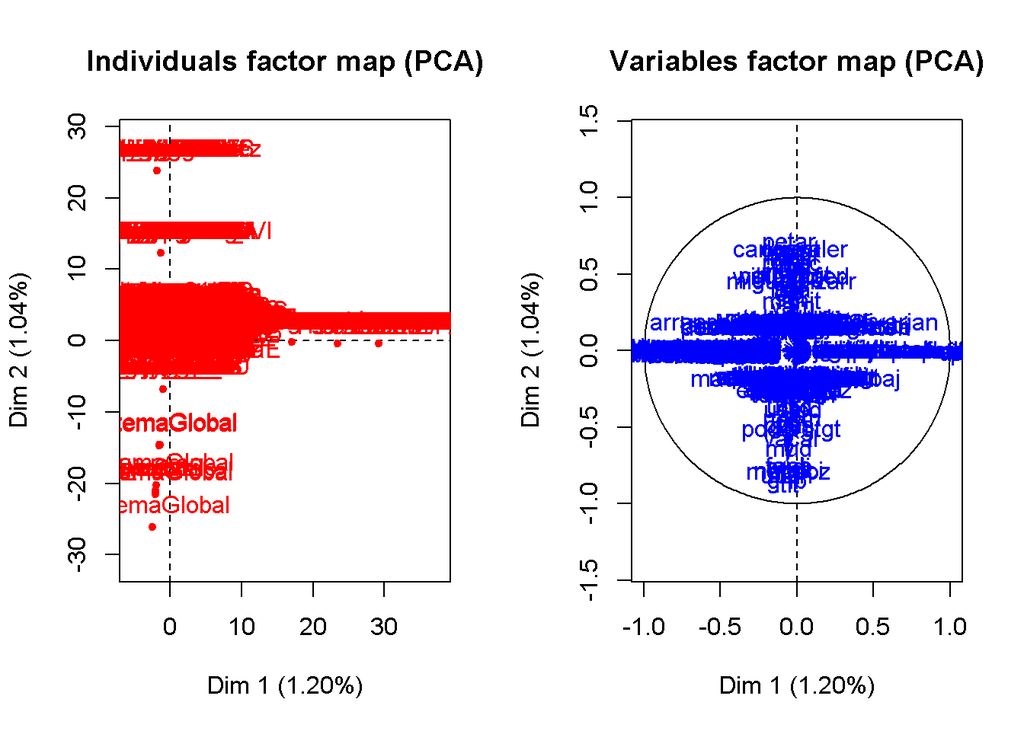

```r
par(mfrow = c(1, 2)) # dividimos la pantalla para recibir dos gráficos
plot(modelo, axes = c(1, 2), choix = "ind", col.ind = "red", new.plot = TRUE)
plot(modelo, axes = c(1, 2), choix = "var", col.var = "blue", new.plot = TRUE)
```

Graficamos el plano principal y el círculo de correlaciones por separado para las componentes principales 1 y 3.

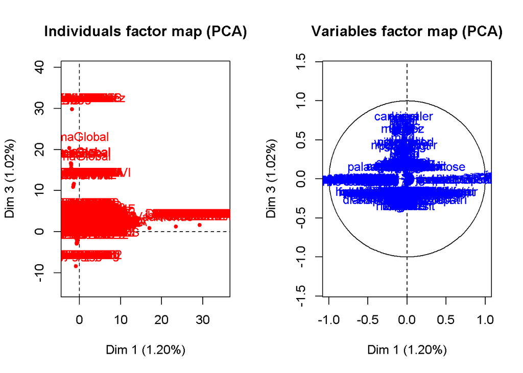

```r
par(mfrow = c(1, 2)) # dividimos la pantalla para recibir dos gráficos
plot(modelo, axes = c(1, 3), choix = "ind", col.ind = "red", new.plot = TRUE)
plot(modelo, axes = c(1, 3), choix = "var", col.var = "blue", new.plot = TRUE)
```

Graficamos el plano principal y el círculo de correlaciones por separado para las componentes principales 2 y 3

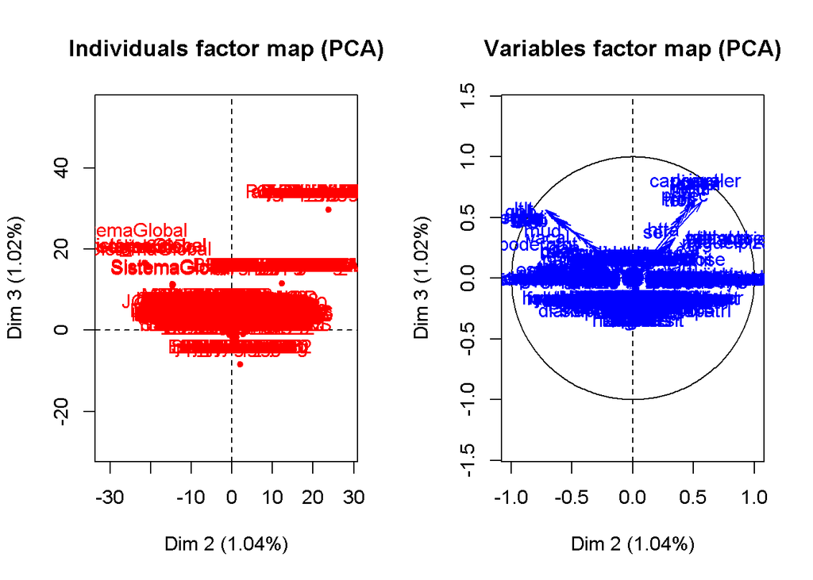

```r
par(mfrow = c(1, 2)) # dividimos la pantalla para recibir dos gráficos
plot(modelo, axes = c(2, 3), choix = "ind", col.ind = "red", new.plot = TRUE)
plot(modelo, axes = c(2, 3), choix = "var", col.var = "blue", new.plot = TRUE)
```

Sin duda alguna la grafica mejor representada es la asociada a a los componentes 1 y 2 , por el hecho de contener la mayor cantidad de informacion.

Asi pues podemos evidenciar de manera visual que en base a la relacion palabras-individuso podriamos considerar la formacion o presencia de 3 a 4 grupos dentro de nuestro modelo.

Otros datos interesantes y de gran importancia son representados por:

Como sabemos que individuos estan mal representados en el modelo?

Se consideran mal representados los cos2 < 60%

De esta manera la Gráfica de los individuos que tengan cos2 >= 0.7 (70%) considerados bien representados esta dada por:

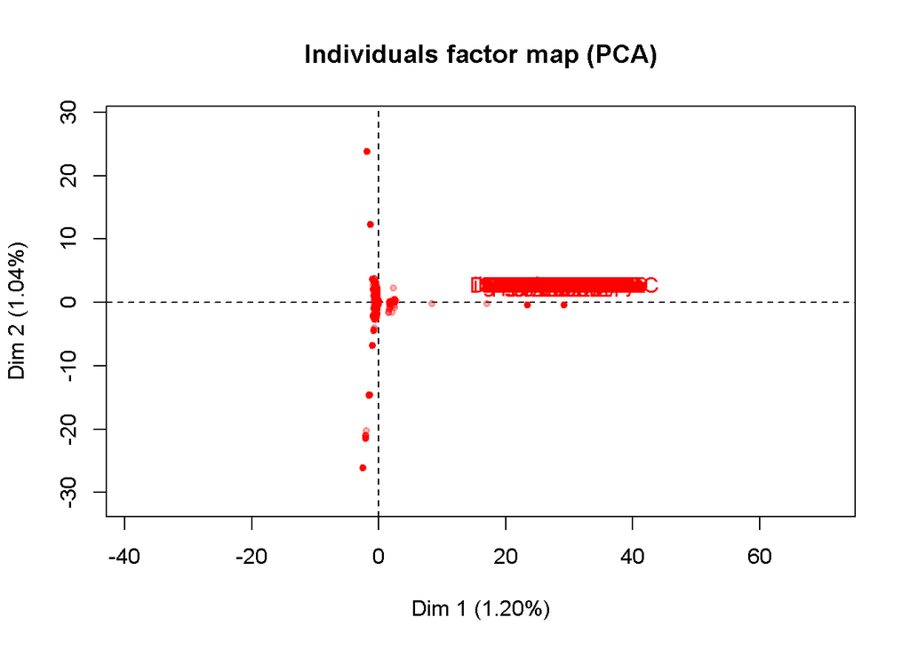

```r
par(mfrow = c(1, 1))
plot(modelo, axes = c(1, 2), choix = "ind", col.ind = "red", new.plot = TRUE, select = "cos2 0.7")
```

De igual manera , surge otra interrogante

Como sabemos que variables estan mal representados en el modelo?

Se consideran mal representados los cos2 < 60%

De esta manera la Gráfica de los variables que tengan cos2 >= 0.9 (90%) considerados bien representados esta dada por:

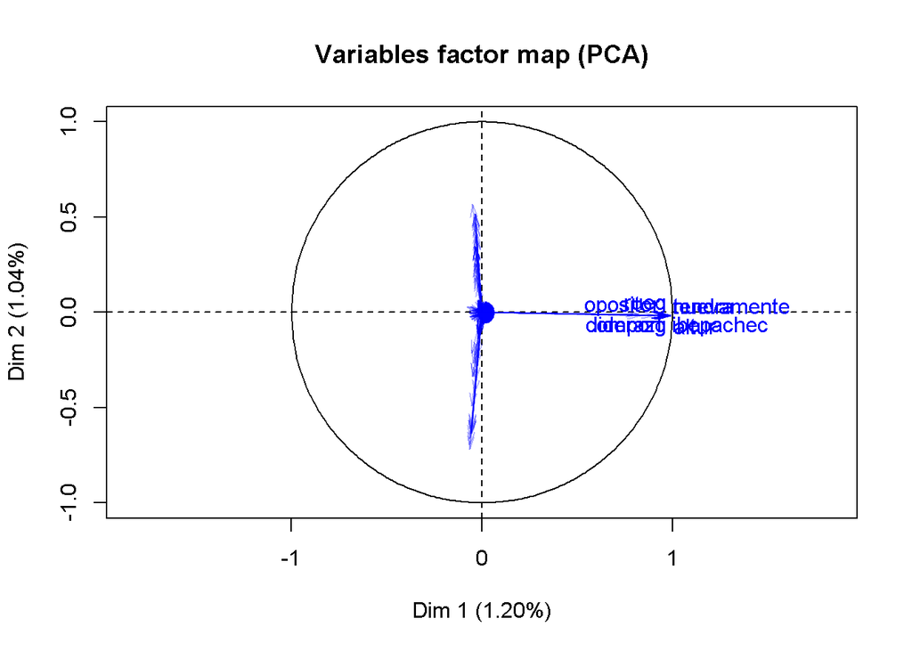

```r
plot(modelo, axes = c(1, 2), choix = "var", col.var = "blue", new.plot = TRUE, select = "cos2 0.9")
```

Realicemos ahora nuestro segundo analisi, acorde al segundo algoritmo o conocido como:

- Metodo de Clasificacion Jerarquica

Primero obtenemos una muestra considerable de los individuos para clasificarlos acorde a las palabras presentes en sus tweets, esta seleccion la realizamos por dos motivos diferentes.

1.- El lenguaje R no nos permitio cargar una matrix de tamaño muy grande para realizar el estudio.

2.- Para tener una mejor visualizacion de la data al momento de graficar.

```r
HDatos <- head(Datos,n=13)
```

Seguidamente calculamos nuevamente los componentes principales de esta nueva muestra.

```r
modelo2 <- PCA(HDatos, scale.unit = TRUE, ncp = 3, graph = FALSE)
```

Procedemos a aplicar el metodo al nuevo modelo, y asi obtenemos las clasificaciones:

```r
res.hcpc <- HCPC(modelo2, nb.clust = -1, consol = TRUE, min = 3, max = 3, graph = FALSE)
res.hcpc
```

```
## **Results for the Hierarchical Clustering on Principal Components**
##    name
## 1  "$data.clust"
## 2  "$desc.var"
## 3  "$desc.var$quanti.var"
## 4  "$desc.var$quanti"
## 5  "$desc.axes"
## 6  "$desc.axes$quanti.var"
## 7  "$desc.axes$quanti"
## 8  "$desc.ind"
## 9  "$desc.ind$para"
## 10 "$desc.ind$dist"
## 11 "$call"
## 12 "$call$t"
##    description
## 1  "dataset with the cluster of the individuals"
## 2  "description of the clusters by the variables"
## 3  "description of the cluster var. by the continuous var."
## 4  "description of the clusters by the continuous var."
## 5  "description of the clusters by the dimensions"
## 6  "description of the cluster var. by the axes"
## 7  "description of the clusters by the axes"
## 8  "description of the clusters by the individuals"
## 9  "parangons of each clusters"
## 10 "specific individuals"
## 11 "summary statistics"
## 12 "description of the tree"
```

De igual manera para este estudio, nos interesa principalmente evidenciar la representacion grafica , ya que es esta, la que nos da los cluster generados en la data, agrupando a los individuos acorde al uso de palabras presentes en sus tweets.

Graficando los cluster con el árbol clasificador

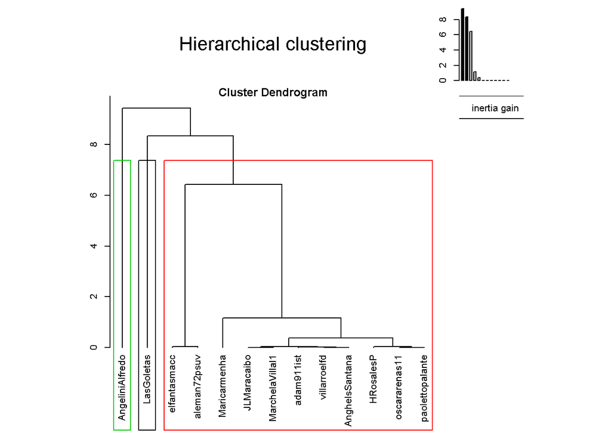

```r
plot(res.hcpc, axes=c(1,2), choice="tree", rect=TRUE,
draw.tree=TRUE, ind.names=TRUE, t.level="all", title=NULL,
new.plot=FALSE, max.plot=15, tree.barplot=TRUE,
centers.plot=FALSE)
```

Otra manera de visualizar:

Graficando los cluster con el árbol clasificador en 3D.

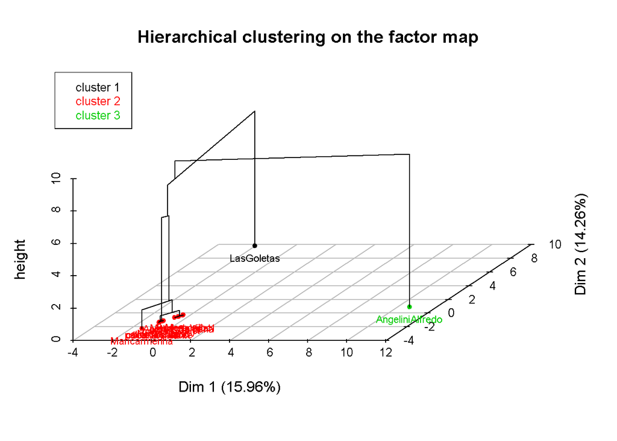

```r
 plot(res.hcpc, axes=c(1,2), choice="3D.map", rect=TRUE,
draw.tree=TRUE, ind.names=TRUE, t.level="all", title=NULL,
new.plot=FALSE, max.plot=15, tree.barplot=TRUE,
centers.plot=FALSE)
```

Concluyendo, es facil evidenciar la presencia de 3 cluster formados al aplicar el metodo de clasificacion jerarquica de igual manera en la relacion documentos(individuos)-variables(palabras) presentes en sus tweets, aunque la muestra es un poco reducida , es facil observar que la tendencia sera que el grupo al cual tiene mas individuos seguira teniendo muchos mas que los otros dos grupos aun y cuando todos iran aumentando en tamaño mientras mas grande sea considerada la muestra tomada.

Para el ultimo analisis procederemos a aplicar el Metodo Clusterización con K-medias.

Lo primero que realizaremos sera seleccionar los componentes y almacenamos para poder ser procesados.

```r
Datoscomponentes <- modelo$ind$coord
```

Luego, surge una inquietud, cual sera el K necesario asociado a la cantidad de grupos que pretendemos buscar?

Pues el siguiente algoritmo nos ayuda a visualizar de manera correcta dicho valor, el pto donde no se evidencia un cambio drastico sera el propicio.

Entonces aplicamos la Selección de K mediante el “Codo de Jambu”

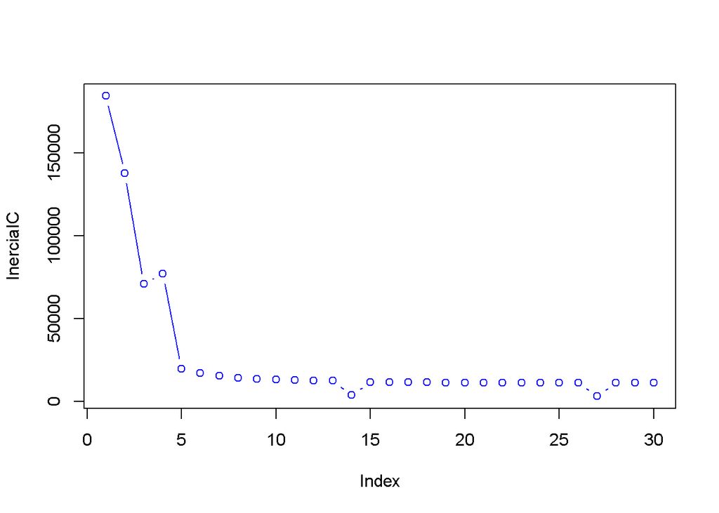

```r
InerciaIC = rep(0, 30)
for (k in 1:30) {
    grupos = kmeans(Datoscomponentes, k)
    InerciaIC[k] = grupos$tot.withinss
}
plot(InerciaIC, col = "blue", type = "b")
```

```r
grupos <- kmeans(Datos, 3, iter.max = 100) #debe de ser sobre el PCA
```

Volvemos al pto de interes, graficaremos el modelo obtenido para poder evidenciar los resultados.

Graficamos los cluster generados y sus centros.

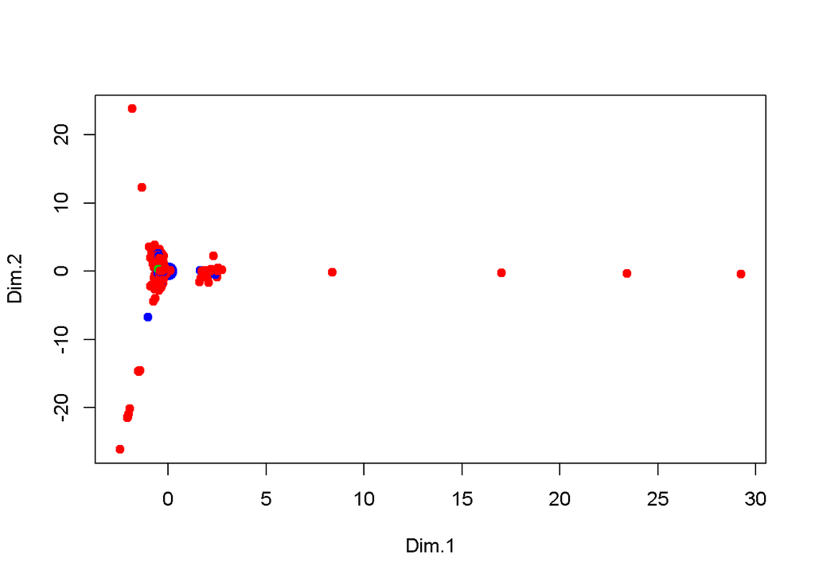

```r
plot(Datoscomponentes, pch = 19)
points(grupos$centers, pch = 19, col = "blue", cex = 2)
points(Datoscomponentes, col = grupos$cluster + 1, pch = 19)
```

A simple vista podemos observar la presencia de al menos dos o tres grupos acorde a los centros generados (ptos azules), sin embargo , existen algunos ptos aislados en la grafica, los mismos son aquellos hemos mencionado anteirormente las cuales son valores atipicos o simplemente estan mal representados en el modelo.

Por ultimo, procederemos guardando la tabla de datos mas una columna con el cluster al que pertenece cada individuo.

```r
NDatos <- cbind(Datoscomponentes, Grupo = grupos$cluster)
head(NDatos,n=5)
```

```
##                      Dim.1       Dim.2      Dim.3 Grupo
## HRosalesP       -0.4177271 -0.91902475  0.3418984     1
## paolettopalante -0.4092240  0.20301806 -0.9424776     1
## elfantasmacc    -0.2859117  0.06790944 -0.4321436     3
## AnghelsSantana  -0.2154186  0.07522643 -0.4953291     1
## MarchelaVillal1 -0.1643816  0.01657131 -0.3383068     1
```

De esta manera se puede concluir considerando que al aplicar los diferentes metodos propuestos y un conjunto de datos mayor o menor varia de forma notable la representacion, mas sin embargo, la tendencia sera de clasificar al conjunto en 2 o 3 grupos directamente relacionado a la data fuente, asi se damos por culminado la justificacion y analisis de los resultados.